# Exploratory Data Analysis

### Alternatives

One problem with boxplots is that they were developed in an era of much smaller data sets and tend to display a prohibitively large number of “outlying values”. One approach to remedy this problem is the letter value plot.

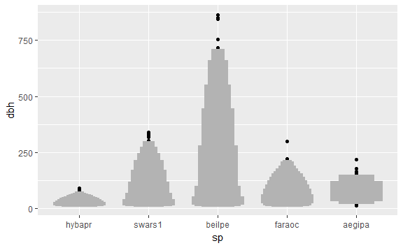

```r
# install.packages("lvplot")
library(lvplot)

ggplot(data_few_sp, aes(sp, dbh)) +
  lvplot::geom_lv()
```

Compare and contrast `geom_violin()` with a faceted `geom_histogram()`, or a colored `geom_freqpoly()`. What are the pros and cons of each method?

```
#> Warning: Removed 47617 rows containing non-finite values (stat_bin).
```

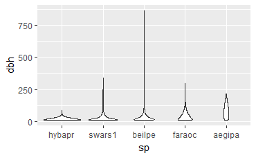

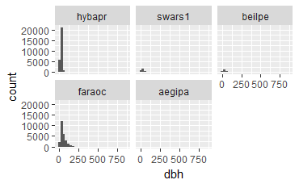

```r
# Left
ggplot(data_few_sp, aes(sp, dbh)) +
  geom_violin()
# Right
ggplot(data_few_sp, aes(dbh)) +
  geom_histogram() +
  facet_wrap(~sp)
```

If you have a small data set, it’s sometimes useful to use `geom_jitter()` to see the relationship between a continuous and categorical variable. The ggbeeswarm package provides a number of methods similar to `geom_jitter()`.

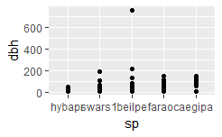

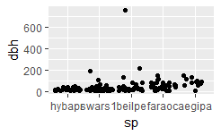

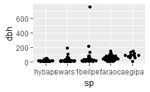

```r
# install.packages("ggbeeswarm")
library(ggbeeswarm)

small_dataset <- data_few_sp %>%
  group_by(sp) %>%
  sample_n(50)

p <- ggplot(small_dataset, aes(sp, dbh))

# Left
p + geom_point()
# Center
p + geom_jitter()
# Right
p + ggbeeswarm::geom_quasirandom()
```

## Two categorical variables

To visualize the co-variation between categorical variables, you’ll need to count the number of observations for each combination. One way to do that is to rely on the built-in `geom_count()`. The size of each circle in the plot displays how many observations occurred at each combination of values (left plot below). Co-variation will appear as a strong correlation between specific x values and specific y values.

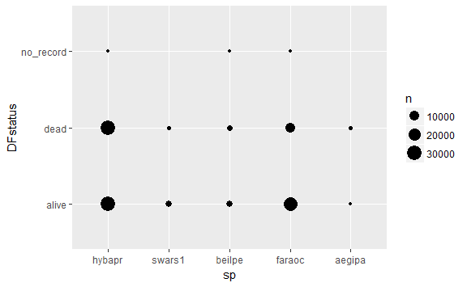

```r
# Simple count
ggplot(data_few_sp) +
  geom_count(aes(x = sp, y = DFstatus))
```

To more clearly show the distribution of `DFstatus` within `sp` (or `sp` within `DFstatus`) you can map bubble size to a proportion calculated over `sp` (or over `DFstatus`):

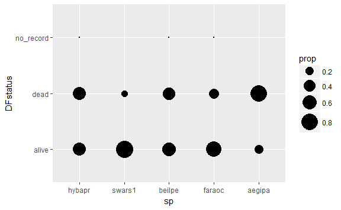

```r
# Proportion; columns sum to 1.
ggplot(data_few_sp, aes(x = sp, y = DFstatus)) +
  geom_count(aes(size = ..prop.., group = sp)) +
  scale_size_area(max_size = 10)
```

Another approach is to compute the count with dplyr:

```r
few_spp_n <- data_few_sp %>%
  count(sp, DFstatus)

few_spp_n
```

```
#> # A tibble: 13 x 3
#>       sp  DFstatus     n
#>   <fctr>     <chr> <int>
#> 1 hybapr     alive 30130
#> 2 hybapr      dead 31409
#> 3 hybapr no_record     8
#> 4 swars1     alive  3189
#> 5 swars1      dead   382
#> 6 beilpe     alive  2252
#> # ... with 7 more rows
```

Then visualize with `geom_tile()` and the fill aesthetic:

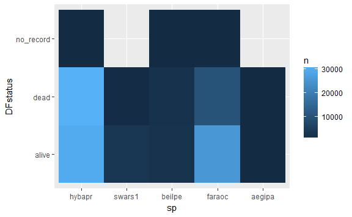

```r
ggplot(few_spp_n, aes(sp, DFstatus)) +
  geom_tile(aes(fill = n))
```

## Two continuous variables

You’ve already seen one great way to visualize the co-variation between two continuous variables: draw a scatterplot with `geom_point()`. You can see co-variation as a pattern in the points. For example, you can see an exponential relationship between the tree diameter (`dbh`) and the above ground biomass (`agb`).

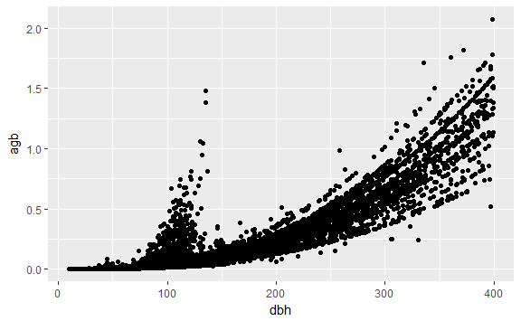

```r
large_dataset <- bci12full7 %>%
  filter(dbh < 400) %>%
  sample_n(100000)

p <- ggplot(large_dataset, aes(dbh, agb))
p + geom_point()
```

Scatterplots become less useful as the size of your data set grows, because points begin to overplot, and pile up into areas of uniform black (as above). You’ve already seen one way to fix the problem: using the `alpha` aesthetic to add transparency.

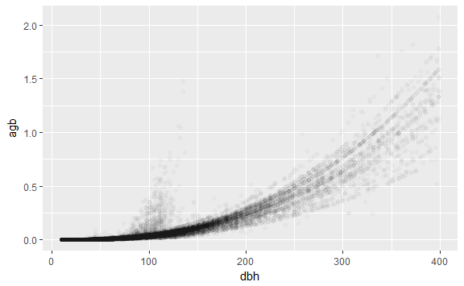

```r
p + geom_point(alpha = 1 / 50)
```

But using transparency can be challenging for very large data sets. Another solution is to use bin. Previously you used `geom_histogram()` and `geom_freqpoly()` to bin in one dimension. Now you’ll learn how to use `geom_bin2d()` and `geom_hex()` to bin in two dimensions.

`geom_bin2d()` and `geom_hex()` divide the coordinate plane into 2d bins and then use a fill color to display how many points fall into each bin. `geom_bin2d()` creates rectangular bins. `geom_hex()` creates hexagonal bins. You will need to install the hexbin package to use `geom_hex()`.

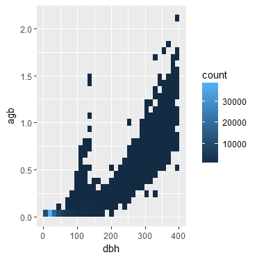

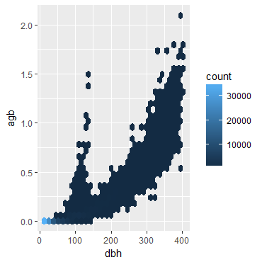

```r
# Left
p + geom_bin2d()

# Right
p + geom_hex()
```

Another option is to bin one continuous variable so it acts like a categorical variable. Then you can use one of the techniques for visualizing the combination of a categorical and a continuous variable that you learned about. For example, you could bin `dbh` and then for each group, display a boxplot:

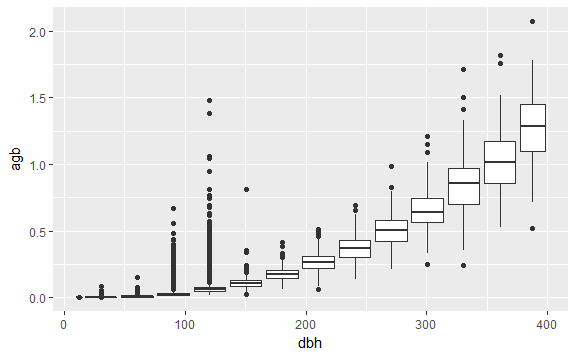

```r
p <- ggplot(large_dataset, aes(dbh, agb))
p + geom_boxplot(aes(group = cut_width(dbh, useful_barwidth)))
```

`cut_width(x, width)`, as used above, divides `x` into bins of width `width`. By default, boxplots look roughly the same (apart from number of outliers) regardless of how many observations there are, so it’s difficult to tell that each boxplot summarizes a different number of points. One way to show that is to make the width of the boxplot proportional to the number of points with `varwidth = TRUE`.

Another approach is to display approximately the same number of points in each bin. That’s the job of `cut_number()`:

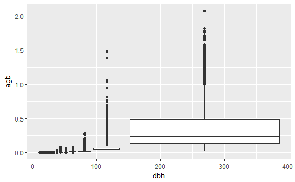

```r
p + geom_boxplot(aes(group = cut_number(dbh, 20)))
```

## Patterns and models

Patterns in your data provide clues about relationships. If a systematic relationship exists between two variables it will appear as a pattern in the data. If you spot a pattern, ask yourself:

- Could this pattern be due to coincidence (i.e. random chance)?
- How can you describe the relationship implied by the pattern?
- How strong is the relationship implied by the pattern?
- What other variables might affect the relationship?
- Does the relationship change if you look at individual subgroups of the data?

A scatterplot of tree diameter (`dbh`) versus above ground biomass (`agb`) shows a pattern: larger tree diameters are associated with larger above ground biomass. The scatterplot also displays strangely high values of `agb`, which appear to correspond with `dbh` values ranging approximately 80-140.

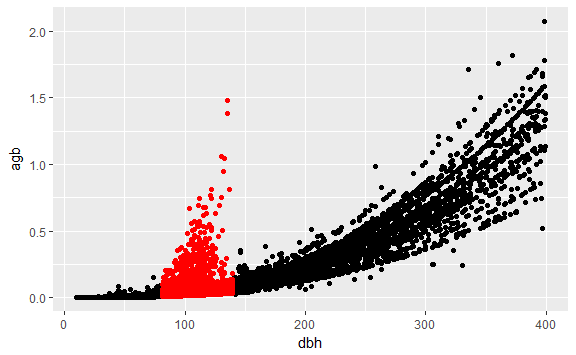

```r
large_strange <- large_dataset %>% filter(dbh > 80 & dbh < 140)

ggplot(data = large_dataset, aes(x = dbh, y = agb)) +
  geom_point() +
  geom_point(data = large_strange, color = "red")
```

Patterns provide one of the most useful tools for data scientists because they reveal co-variation. If you think of variation as a phenomenon that creates uncertainty, co-variation is a phenomenon that reduces it. If two variables co-vary, you can use the values of one variable to make better predictions about the values of the second. If the co-variation is due to a causal relationship (a special case), then you can use the value of one variable to control the value of the second.

Models are a tool for extracting patterns out of data. For example, consider the `large_dataset` data; `dbh` and `agb` are tightly related. It’s possible to use a model to remove the very strong relationship between `dbh` and `agb` so we can explore the subtleties that remain. The following code fits a model that predicts `agb` from `dbh` and then computes the residuals (the difference between the predicted value and the actual value). The residuals give us a view of the `agb` of a tree, once the effect of `dbh` has been removed.

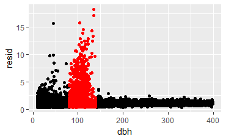

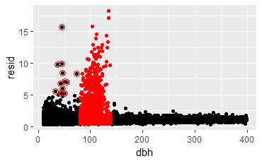

```r
library(modelr)

mod <- lm(log(agb) ~ log(dbh), data = large_dataset)
resid_added <- large_dataset %>%
  add_residuals(mod) %>%
  mutate(resid = exp(resid))

# Left
resid_strange <- resid_added %>% filter(dbh > 80 & dbh < 140)
p <- ggplot(data = resid_added, aes(x = dbh, y = resid)) +
  geom_point() +
  geom_point(data = resid_strange, color = "red")
p

# Right
resid_strange_too <- resid_added %>% filter(dbh < 80, resid > 5)
p + geom_point(data = resid_strange_too, size = 3, colour = "red", shape = 1)
```

Once you’ve removed the strong relationship between `dbh` and `agb`, you can see some additional strange measurements.